# Hierarchical models

Lucas Deschamps

5 april 2019

## Packages

`rstan`: Hamiltonian Monte-Carlo. Installation guide is [here](https://github.com/stan-dev/rstan/wiki/RStan-Getting-Started).

`rstanarm`:

- a very efficient, optimized and innovative modular package.
- Try to mimic the behavior of classical frequentist packages
- Fast for simple problems : pre-compiled models

`brms`:

- a very flexible and powerfull package (vast set of models implemented, possibility to add hand-made code, to implement distributions…)
- slower for simple problems : need compilation

# Introduction

## Hierarchical models

The world is structured (populations in species, in regions; cells in organ, in individuals)…

… And we measure different drivers at different levels of organization (biotic interactions regulates populations size within lakes, but the presence or absence of a species is also dependant on its ability to get there!)…

… But informations flow through the different levels. And we want to exploit it to model the world.

So, let’s enter in the wonderfull world of hierarchical models!

## Background

Mr Maxwell, descendant of the famous physicist, have sold his coffee brand to K***t

Moved to Trois-Rivieres, with the strong wish to open a new kind of *café*

But the competition is hard, and he needs to do a market investigation…

# Number of consumers : a simple mean model

## Goal

What is the mean number of consumers in Trois-Rivières’ *cafés* at the rush hour?

Mr Maxwell hired *professionals* to quantify the number of consumers in each *café* at 8h.

## Results

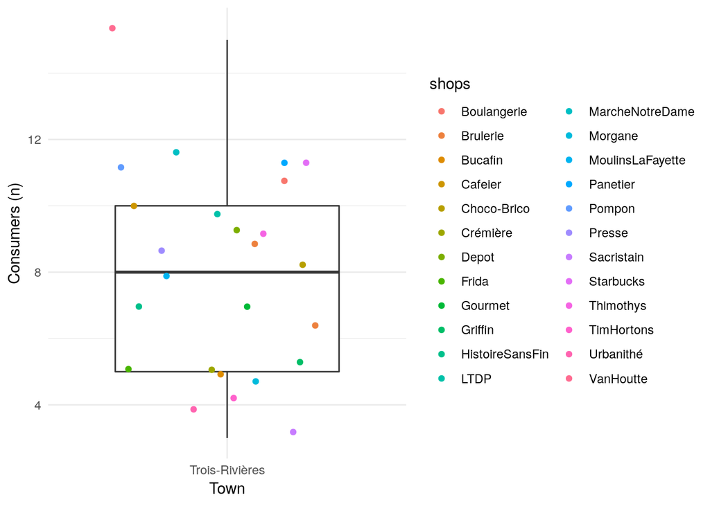

## Choosing the likelihood

What do we know about the number of consumers?

- Integers
- Strictly positive
- Variance $\propto$ mean : if a shop having in average three consumers starts to receive more than height consumers some days, both mean and variance will increase!

=> Poisson distribution!

## Poisson distribution

- Poisson distribution is parametrized by a single parameter (representing mean and variance), $\lambda > 0$.
- This allows the formulation of the *likelihood function*:

$$y_i \sim Poisson(\lambda)\\
P(y_i | \lambda) = \frac{\lambda^{y_i} e^{-\lambda}}{y_i!}\\$$

## Data Generating Process

- A likelihood

$$y_i \sim Poisson(\lambda)$$

- Priors incorporating our knowledge about the parameters

$$\lambda \sim logNormal(\mu = log(??), \sigma = log(??))$$

Because $\lambda$ is strictly positive, we have to choose a prior only defined over $(0, +\infty)$. The log-normal distribution is strictly positive. It’s $\mu$ and $\sigma$ corresponds to the mean and standard-deviation on the log-scale. If we think their is in average 10 consumers, we should put a prior defined by $\mu = log(10)$.

## Looking at the priors

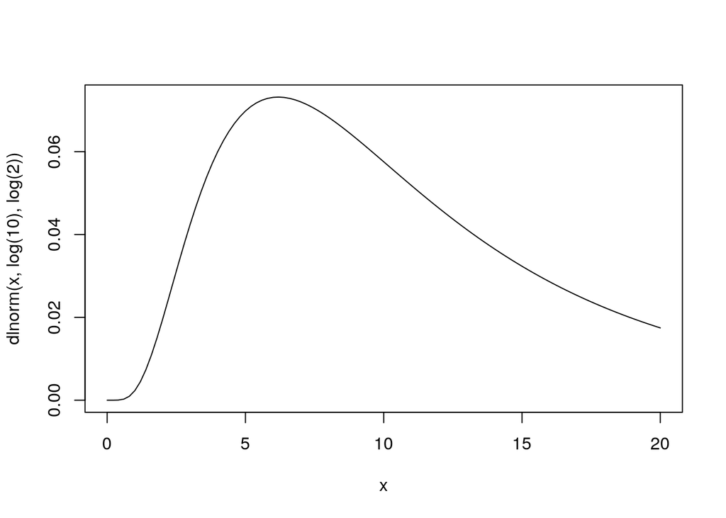

```r
curve(dlnorm(x, log(10), log(2)), from = 0, to = 20)
```

## Simulating from Data Generating Process

```r
## Load library : tidy df manipulation and plottings
library(tidyverse)

## Create the list of coffe shops
shops <-  c("Morgane", "Starbucks", "LTDP", "Frida", "Presse", "TimHortons", "Gourmet",
            "Depot", "Brulerie", "Choco-Brico", "Sacristain", "VanHoutte", "Crémière" ,
            "Cafeier", "Griffin", "Panetier", "Bucafin", "Urbanithé", "MarcheNotreDame",
            "Brulerie", "MoulinsLaFayette", "HistoireSansFin", "Pompon", "Boulangerie",
            "Thimothys")
## Set the seed of the random number generator
set.seed(999)
## Sample parameters of the model
N = length(shops) # Number of samples
mu_lambda <- 10 # Expected mean of beta_0
sigma_lambda <- 2 # Expected standard deviation of beta_0
lambda <- rlnorm(1, log(mu_lambda), log(sigma_lambda)) # beta_0
y <- rpois(N, lambda) # Sample the observed waiting time

# Assemble in a data.frame
D <- data.frame(town = "Trois-Rivières", consumers = y, shops = shops)

# Boxplot of the result
D %>% ggplot(aes(x = town, y = consumers)) +
  geom_boxplot() +
  geom_jitter(aes(color = shops)) +
  ylab("Consumers (n)") +
  xlab("Town") +
  theme_minimal()
```

# Varying intercepts

## Goal

Which *cafés* are the potentially more important concurents?

Mr Maxwell hired *professionals* to quantify the number of consumers in each *café* at 8h30, **repeatedly**.

## Results

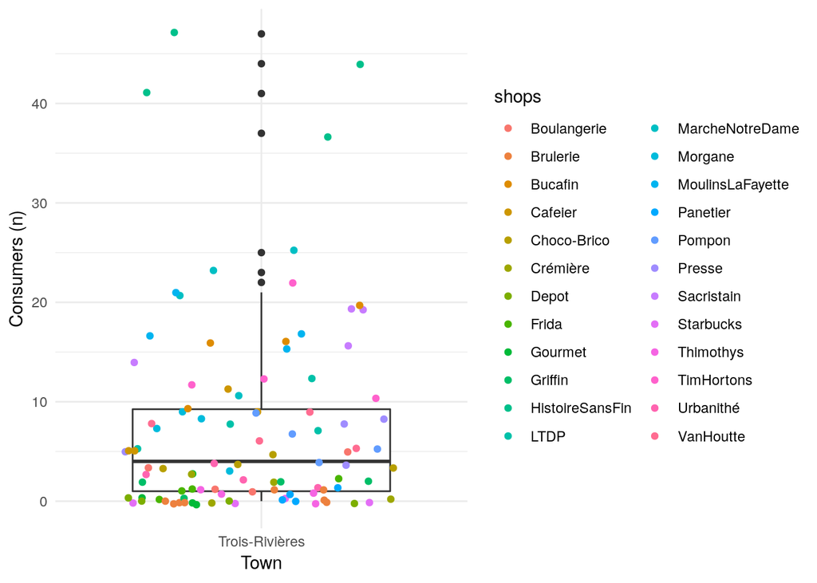

## Results

[figure not shown]

## A simple intercept model

- A likelihood

$$y_i \sim Poisson(\lambda_i)\\$$
- An equation and a link function

$$log(\lambda_i) = \beta_0 + \beta_s \Leftrightarrow \lambda_i = e^{\beta_0 + \beta_s}$$
- Priors
$$\beta_0 \sim Normal(log(??), log(??))\\
\beta_s \sim Normal(0, log(??))$$

The link function ensure that $\lambda$ will stay in the positive area. Because parameters are on the log scale, we do not need to use the lognormal distribution anymore, but we still have to think about the log of what we think about parameters. The global mean, $\beta_0$, should be 10, and the individual shops might vary by more or less 5 consumers. However, we have to note that because of the exponent, the shops deviation ($\beta_s$) to the population mean ($\beta_0$) will be multiplicative instead of additive!

## Simulating from Data Generating Process

```r
## Create a data frame
X_long <- data.frame(shops = rep(shops, each = 4))

## Create a design matrix
library(useful)
X_large <- build.x(~ shops, X_long, contrasts = F)[,-1]

## Sample from the prior
set.seed(999)
b_shops <- rnorm(ncol(X_large), 0, log(5)) # Hierarchical parameters
b_0 <- rnorm(1, log(10), log(2))

## Compute linear predictor
mu <- exp(b_0 + X_large %*% b_shops)

## Sample observations
y <- rpois(nrow(X_large), mu)

D <- data.frame(shops = X_long$shops, consumers = y, town = "Trois-Rivières",
                type = "Observed")

D %>% ggplot(aes(x = town, y = consumers)) +
  geom_boxplot() +
  geom_point(aes(col = shops), position = "jitter") +
  ylab("Consumers (n)") +
  xlab("Town") +
  theme_minimal()
```

[output not shown]

## Simulating from Data Generating Process

[figure not shown]

```r
D %>% mutate(shops = reorder(.$shops, .$consumers, median, na.rm = T)) %>%
  ggplot(aes(x = shops, y = consumers, col = shops)) +
  geom_boxplot() +
  guides(color = F) +
  ylab("Consumers (n)") +
  xlab("Shops") +
  theme_minimal() +
  theme(axis.text.x = element_text(angle=45))
```

## Fit the non-hierarchical intercepts model with `brms`

```r
## Load library : flexible bayesian model fitting
library(brms)
## Formula
form_int <- bf(consumers ~ shops, family = poisson)

## Get priors
get_prior(form_int, data = D)

## Define priors
priors_int <- c(prior(normal(0,5), class = Intercept),
                prior(normal(0,5), class = b))

## Sample from the posterior
fit_int <- brm(formula = form_int, prior = priors_int, data = D,
               chains = 4, iter = 2000,
               cores = parallel::detectCores())
fit_int
```

## Check the sampling

```r
fit_int
```

```
 Family: poisson
  Links: mu = log
Formula: consumers ~ shops
   Data: D (Number of observations: 100)
Samples: 4 chains, each with iter = 2000; warmup = 1000; thin = 1;
         total post-warmup samples = 4000

Population-Level Effects:
                      Estimate Est.Error l-95% CI u-95% CI Eff.Sample Rhat
Intercept                 0.88      0.31     0.26     1.45        414 1.01
shopsBrulerie            -2.46      0.81    -4.25    -1.03       1559 1.00
shopsBucafin              1.83      0.33     1.21     2.50        463 1.01
shopsCafeier              1.11      0.36     0.41     1.83        526 1.01
shopsChocoMBrico          0.40      0.40    -0.39     1.20        664 1.01
shopsCrémière            -0.76      0.55    -1.92     0.30       1205 1.00
shopsDepot               -5.65      2.62   -12.09    -1.92       1618 1.00
shopsFrida               -1.01      0.63    -2.38     0.10       1126 1.00
shopsGourmet             -1.33      0.68    -2.79    -0.09       1175 1.00
shopsGriffin             -0.56      0.52    -1.63     0.42        993 1.00
shopsHistoireSansFin      2.86      0.31     2.28     3.50        432 1.01
shopsLTDP                 1.18      0.35     0.51     1.89        529 1.01
shopsMarcheNotreDame      2.10      0.33     1.48     2.78        445 1.01
shopsMorgane              1.01      0.36     0.32     1.73        526 1.01
shopsMoulinsLaFayette     1.97      0.33     1.36     2.64        470 1.01
shopsPanetier            -1.79      0.82    -3.61    -0.40       1792 1.00
shopsPompon               0.93      0.37     0.23     1.65        561 1.01
shopsPresse               0.93      0.36     0.23     1.64        564 1.01
shopsSacristain           1.94      0.33     1.33     2.61        468 1.01
shopsStarbucks           -5.74      2.79   -12.47    -1.79       1828 1.00
shopsThimothys           -1.33      0.71    -2.89    -0.11       1279 1.00
shopsTimHortons           1.74      0.34     1.12     2.43        471 1.01
shopsUrbanithé           -0.02      0.44    -0.90     0.85        793 1.00
shopsVanHoutte            1.05      0.36     0.36     1.76        551 1.01

Samples were drawn using sampling(NUTS). For each parameter, Eff.Sample
is a crude measure of effective sample size, and Rhat is the potential
scale reduction factor on split chains (at convergence, Rhat = 1).
```

We can look at the chains and posterior distributions with the simple following command

```r
plot(fit_int)
```

[No divergent transition nor BFMI warmings](https://mc-stan.org/misc/warnings.html) : the build-in diagnostics of the sampler did not reveal problematic behavior (essentially problems with the curvature of the posterior surface). See [here](https://www.martinmodrak.cz/2018/02/19/taming-divergences-in-stan-models/).

Rhat : $\hat R$, indicates the mixing/convergence of the different chains of the MCMC sampler. Should be equal to 1, or <1.02. A problem of mixing might arise from a model poorly identified, in that case, we have to rethink about the model and/or the prior.

Eff.Sample : Effective Monte-Carlo Sample Size, indicates the efficiency of posterior sampling. Should be >400 to trust the mean/median estimates, and possibly higher to have reliable estimates of quantiles 0.275 and 0.975 (which are not really useful anyway.)

## Posterior predictive checks

PPC are a good solution to verify our model captures essential features of the data,and is not out (over/under dispersed, unable to capture observed patterns…).

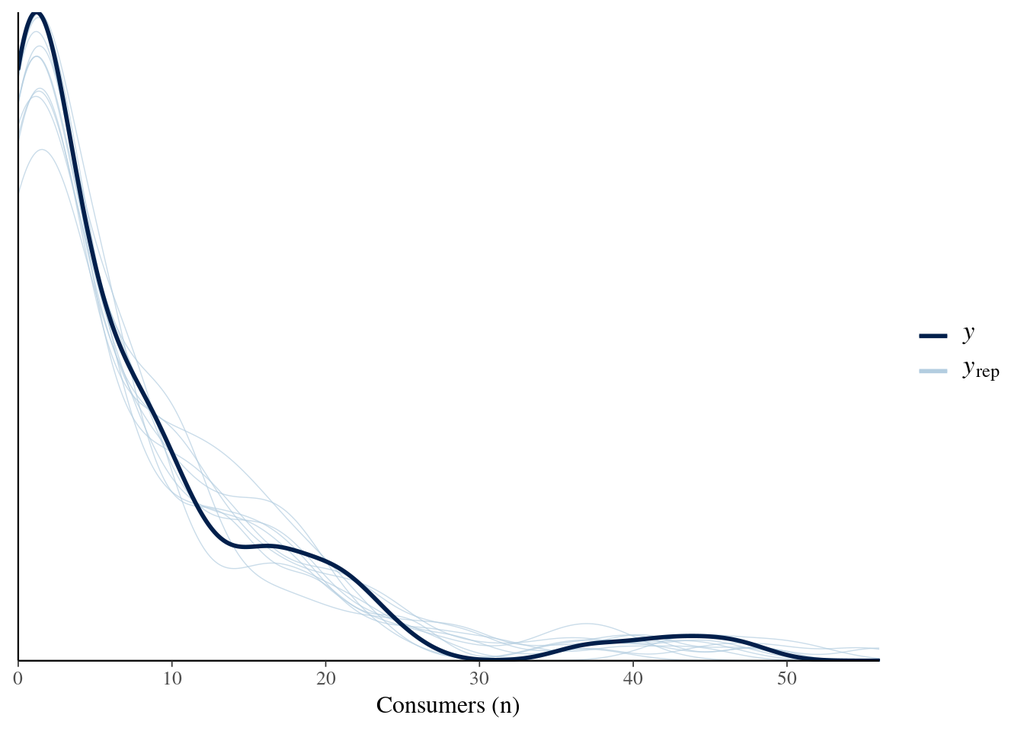

```r
pp_check(fit_int, type = "dens_overlay") +
  xlab("Consumers (n)")
```

## We should do better!

Actually, we are repeatidly sampling in different *cafés* from the same population.

The previous model:

- consider each *café* as being independant
- tries to estimate the parameter of each *café* from only a few data points : enormous standard error far shops with low available information!
- does not care about what we could learn from the population

It is like if each visit was its first time => no pooling

## Visualizing the uncertainty

Remember that mean $\propto$ variance! Which implied that a more popular *cafe* is also more variable…

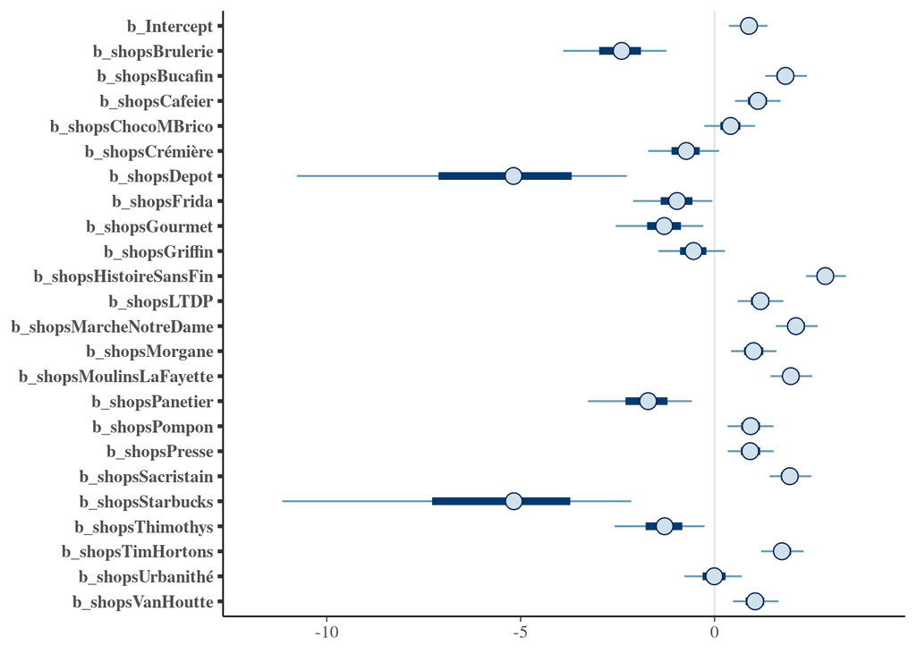

```r
stanplot(fit_int)
```

## We should do better : hierarchical models!

Hierarchical models allow to learn simultaneously about the population and each *café* estimates : each visit in a *café* informs the model about the characteristics of the others.

Each estimate from the population helps to improve the other estimates through and *adaptive prior*!

## Varying intercept model

The principle of a varying intercept model is to learn information about the population of *cafe* simultaneously to the learning of information about individual estimates. This is translated in the following model by estimating the dispersion (= standard deviation) of the population of *cafe*, $\sigma_{\beta_s}$, instead of providing it as in the previous model.

Because this dispersion is now estimated, $\sigma_{\beta_s}$ is a parameter and need a prior.

- A likelihood
  $$y_i \sim Poisson(\lambda_i)\\
  \lambda_i = e^{\beta_0 + \beta_s}\\$$
- Priors
  $$\beta_0 \sim Normal(log(??), log(??))\\
  \beta_s \sim Normal(0, \sigma_{\beta_s})$$
- Hyperpriors
  $$\sigma_{\beta_s} \sim N+(log(??), log(??))$$

## Fit the varying intercept model with `brms`

The `brms` (and [`rstanarm`](https://cran.r-project.org/web/packages/rstanarm/vignettes/glmer.html)) syntax for hierarchical model is similar to the one in `lme4`.

```r
## Formula
form_varint <- bf(consumers ~ (1|shops), family = poisson)

## Get priors
get_prior(form_varint, data = D)

## Define priors
priors_varint <- c(prior(normal(0,5), class = Intercept),
                   prior(normal(0,0.5), class = sd))

## Sample from the posterior
fit_varint <- brm(formula = form_varint, prior = priors_varint, data = D,
               chains = 4, iter = 2000,
               cores = parallel::detectCores())
fit_varint
```

## Check the sampling

```r
fit_varint
```

```
 Family: poisson
  Links: mu = log
Formula: consumers ~ (1 | shops)
   Data: D (Number of observations: 100)
Samples: 4 chains, each with iter = 2000; warmup = 1000; thin = 1;
         total post-warmup samples = 4000

Group-Level Effects:
~shops (Number of levels: 24)
              Estimate Est.Error l-95% CI u-95% CI Eff.Sample Rhat
sd(Intercept)     1.38      0.19     1.05     1.78        644 1.01

Population-Level Effects:
          Estimate Est.Error l-95% CI u-95% CI Eff.Sample Rhat
Intercept     1.20      0.29     0.64     1.75        461 1.01

Samples were drawn using sampling(NUTS). For each parameter, Eff.Sample
is a crude measure of effective sample size, and Rhat is the potential
scale reduction factor on split chains (at convergence, Rhat = 1).
```

```r
plot(fit_varint)
```

## Posterior predictive checks

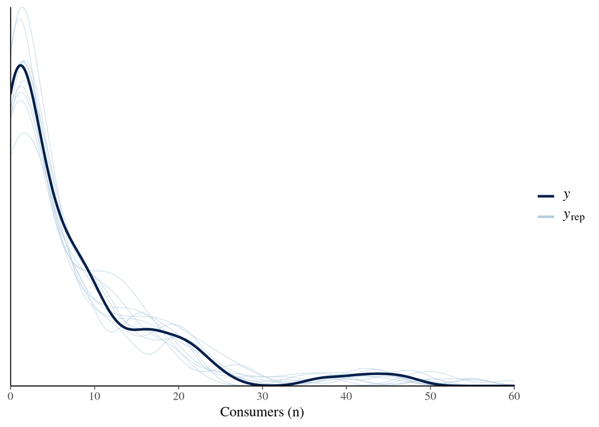

```r
pp_check(fit_varint, type = "dens_overlay") +
  xlab("Consumers (n)")
```

## Posterior predictive checks

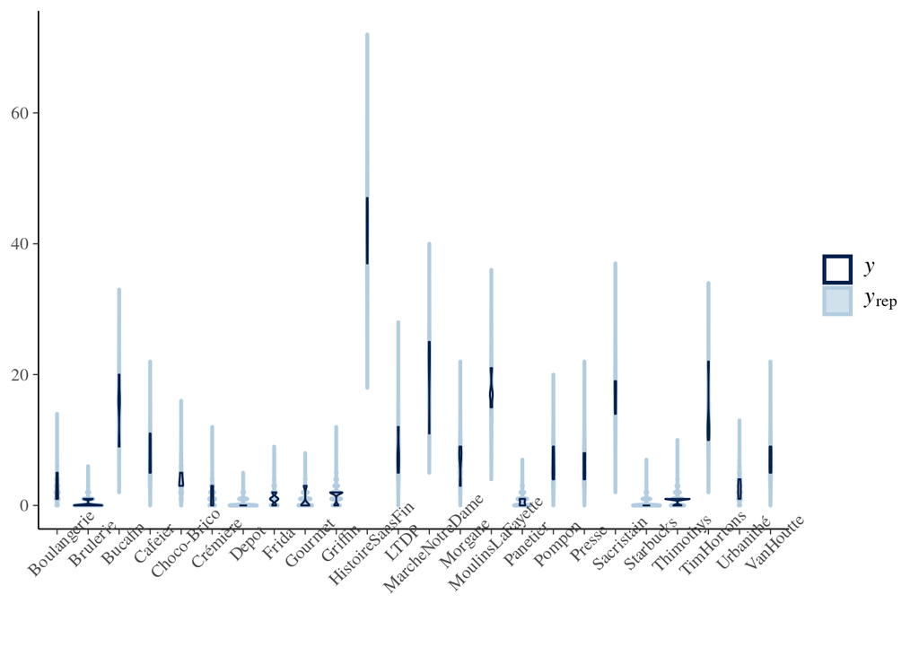

```r
pp_check(fit_varint, type = "violin_grouped", group = "shops") +
  theme(axis.text.x = element_text(angle=45))
```

## Model comparison : shrinkage of parameters

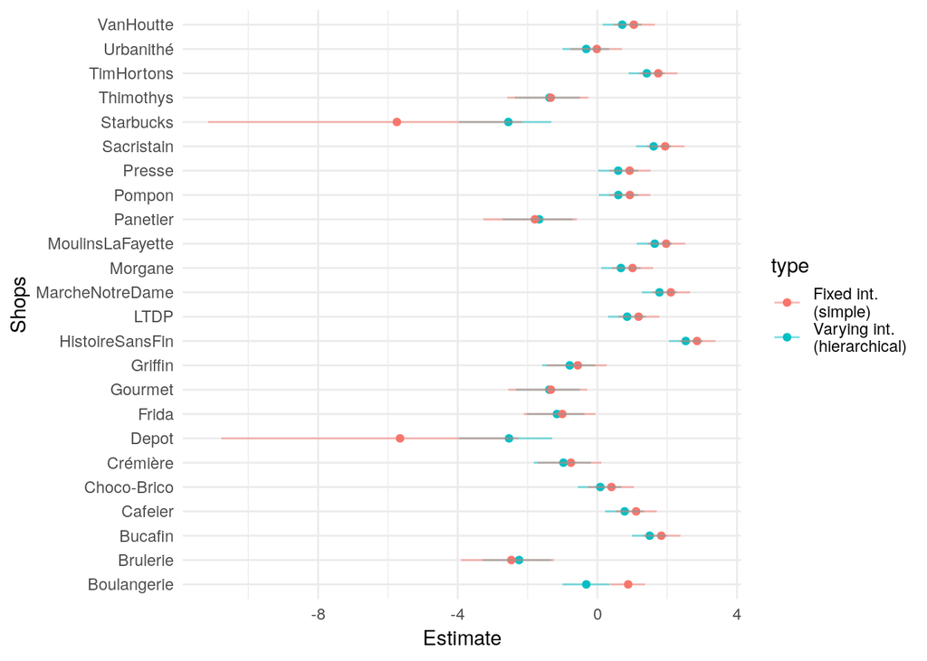

```r
## Extract hierarchical estimates
Ints_ranef <- as.data.frame(ranef(fit_varint, probs = c(0.05, 0.95))$shops) %>%
  rename(Estimate = Estimate.Intercept,
         cinq = `Q5.Intercept`, qvquinze = `Q95.Intercept`) %>%
  mutate(type = "Varying int.\n(hierarchical)", shops = rownames(.))
## Extract classical intercepts
Ints_fix <- as.data.frame(fixef(fit_int, probs = c(0.05, 0.95))) %>%
  rename(cinq = `Q5`, qvquinze = `Q95`) %>%
  mutate(type = "Fixed int.\n(simple)", shops = Ints_ranef$shops)


bind_rows(Ints_ranef, Ints_fix) %>%
  ggplot(aes(x = Estimate, y = shops, col = type, group = type)) +
  geom_point() +
  geom_errorbarh(aes(xmin = cinq, xmax = qvquinze), height =0, alpha = 0.5) +
  ylab("Shops") +
  theme_minimal()
```

We can observe two phenomenoms in the previous plot :

- There is a global *shrinkage*. The estimates of every cafe tends to be closer to zero than in the simple intercept model. The varying intercept model tends to consider that each estimates is a particular realization of the underlying process (some *cafe* are more popular than others). However, what we want is to determine the underlying process, not to decribe exactly the contingencies which leads to our data set. Therefore, in absence of strong information leading to a particular estimate, varying intercepts models will consider *cafe* as being closer to the population mean than the observed mean (see also next plot).
- The influence of the population will be more important for *cafe* for which there is less information (Depot and Starbucks). Both mean estimates and uncertainty are greatly reduced for this two shops.

In summary : the less information there is about a particular entity, the more we have to rely on information at the population level to estimate it accurately. Possibly, with an infinity of data points for each cafe, we would know its mean number of consumer with such a certainty that population estimates would note carry information anymore.

*Exercise :* Run again the complete process but with a greater number of observations per *cafe*!

## Model comparison: shrinkage of predictors and predictions

The following plot display the value of the predictor (the mean of the poisson distribution, $\lambda$), for each *cafe*. We can se that the further the mean is from the population mean, the more it is shrinked toward it.

[figure not shown]

```r
## Create
Newdata <- data.frame(shops = rep(shops, each = 1),
                      Town = "Trois-Rivières")
## Compute predictions of the simple intercepts model
pred_int <- fitted(fit_int, probs = c(0.05, 0.95), newdata = Newdata, robust = T)
Pred_int <- data.frame(type = "Fixed int.\n(simple)",
                       consumers = pred_int[,1],
                       cinq = pred_int[,3],
                       qvquinze = pred_int[,4])
## Assemble prediction with the predictors
D_int <- Newdata %>% bind_cols(Pred_int)

## Compute predictions of the varying intercepts model
pred_varint <- fitted(fit_varint, probs = c(0.05, 0.95), newdata = Newdata, robust = T)
Pred_varint <- data.frame(type = "Varying int.\n(hierarchical)",
                       consumers = pred_varint[,1],
                       cinq = pred_varint[,3],
                       qvquinze = pred_varint[,4])
## Assemble prediction with the predictors
D_varint <- Newdata %>% bind_cols(Pred_varint)

## Extract population mean
Est_b0 <- fixef(fit_varint)

bind_rows(D_int, D_varint) %>%
  mutate(shops = reorder(.$shops, .$consumers, median, na.rm = T)) %>%
  ggplot(aes(x = shops, y = consumers, col = type)) +
  geom_boxplot(alpha = 0.5) +
  geom_hline(yintercept = exp(Est_b0[,1]), linetype = "dotted") +
  ylab(expression(paste(lambda))) +
  xlab("Shops") +
  theme_minimal() +
  theme(axis.text.x = element_text(angle=45))
```

## Model comparison : predictive density

The looo-IC is an sphisticated information criterion, which estimates the effective number of parameters (`p_loo`), provide built-in diagnostics to inform about the reliability of the inference based on it (and about possible [model mispecification](https://cran.r-project.org/web/packages/loo/vignettes/loo2-example.html)),while carrying the uncertainty of the fitting process (each loo-IC is distributed normally with a mean and a standard-error).

A lower loo-IC means that the ability of the model to predict future data from the same data generating process is greater. It is calculated from a measure of the fit of the model to the observed data (`elpd_loo`), penalized for the number of effective sample of parameters, the parameter that had to be estimated by the model (`p_loo`).

```r
(loo_int <- loo(fit_int))
```

```
Computed from 4000 by 100 log-likelihood matrix

         Estimate   SE
elpd_loo   -200.7 11.5
p_loo        21.7  3.0
looic       401.5 23.1
------
Monte Carlo SE of elpd_loo is NA.

Pareto k diagnostic values:
                         Count Pct.    Min. n_eff
(-Inf, 0.5]   (good)     91    91.0%   362
 (0.5, 0.7]   (ok)        8     8.0%   400
   (0.7, 1]   (bad)       1     1.0%   155
   (1, Inf)   (very bad)  0     0.0%   <NA>
See help('pareto-k-diagnostic') for details.
```

```r
(loo_varint <- loo(fit_varint))
```

```
Computed from 4000 by 100 log-likelihood matrix

         Estimate   SE
elpd_loo   -201.4 10.7
p_loo        19.9  2.5
looic       402.9 21.3
------
Monte Carlo SE of elpd_loo is NA.

Pareto k diagnostic values:
                         Count Pct.    Min. n_eff
(-Inf, 0.5]   (good)     92    92.0%   998
 (0.5, 0.7]   (ok)        6     6.0%   624
   (0.7, 1]   (bad)       2     2.0%   151
   (1, Inf)   (very bad)  0     0.0%   <NA>
See help('pareto-k-diagnostic') for details.
```

The following command allow to compare the two models

```r
print(loo_compare(loo_int, loo_varint), simplify = F)
```

```
           elpd_diff se_diff elpd_loo se_elpd_loo p_loo  se_p_loo looic
fit_int       0.0       0.0  -200.7     11.5        21.7    3.0    401.5
fit_varint   -0.7       2.0  -201.4     10.7        19.9    2.5    402.9
           se_looic
fit_int      23.1
fit_varint   21.3
```

- The two models, the simple and the hierarchical one have the same predictive ability.
- The fit of the simple model to the particular dataset is slightly better.
- The the effective number of parameters of the hierarchical model is lower than the simple model (by 2). How is it possible, while we estimated a population’s standard-deviation in addition to the same number of intercepts?

## Effective number of parameters

In the world of adaptive priors, or more generally *regularizing* or *informative* prior, the number of parameters to estimate is not known in advance.

The relative contribution of the information contained in the prior *vs.* the information contained in data influenced the *effective number of parameters*. If the parameters is uniquely defined by its prior, there is no parameter to estimate!

A simple example : even with this very simple model, the effective number of parameters will change in function of the “true” mean.

If the mean is close to zero, the prior will have a great influence, informating the model that the mean cannot be negative. If the mean is far from zero, the influence of the prior will be negligeable, given that every value from zero to the infinity is equally probable.

$$y_i \sim Normal(\mu, \sigma)\\
\mu \sim U(0, +\infty)$$

```r
## Formula
form <- bf(y ~ 1)

## Low mean data
D_low <- data.frame(y = rnorm(100, mean = 0.1, sd = 1))
## High mean data
D_high <- data.frame(y = rnorm(100, mean = 50, sd = 5))

## Explore priors
get_prior(form, data = D_low)

## Define priors (remplacing infinity by an enormous number)
priors <- prior(uniform(0, 1000000000000), class = Intercept)


## Fit the low mean data
fit_low <- brm(formula = form, prior = priors, data = D_low)
## Fit the high mean data
fit_high <- brm(formula = form, prior = priors, data = D_high)
```

```
            p_loo
fit_low  1.180004
fit_high 2.469511
```

## Sampling new levels

Because the model have learn the the distribution of the number of consumers in Trois-Rivières, we can predict potential distributions of newly installed *cafés*.

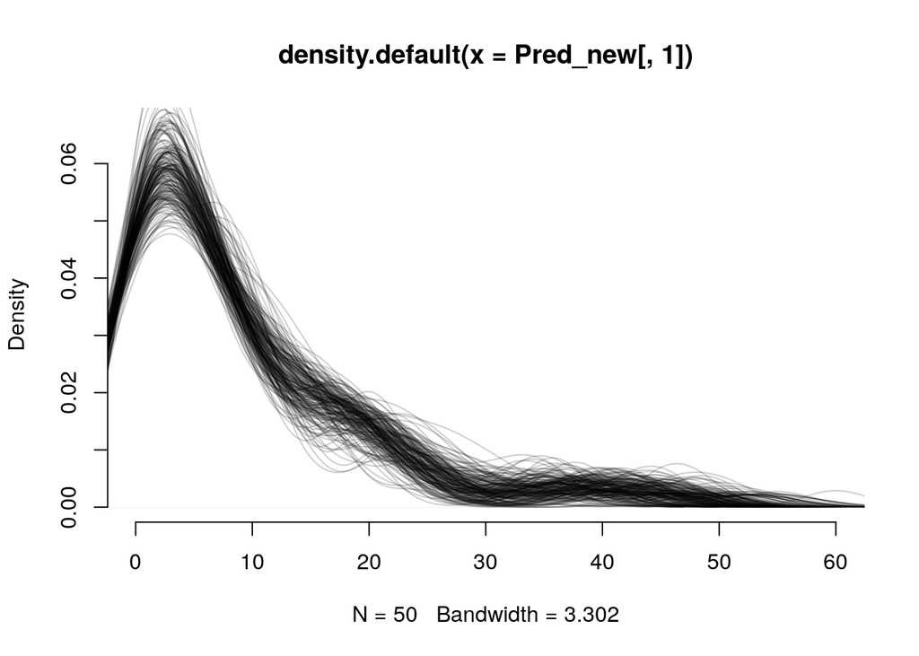

```r
## Set the random seed
set.seed(999)
## Create new data for new cafe
Newdata <- data.frame(shops = rep(c("Cora", "Eggsqui",
                                    "AuCafeBienheureux", "IloveCoffee"), each = 50))
## Compute predictions
Pred_new <- predict(fit_varint, newdata = Newdata, allow_new_levels = T,
                    summary = F, nsamples = 50)

## Plots the density which represents the population and the uncertainty about it
plot(density(Pred_new[,1]), xlim= c(0,60), bty = "n",
                                 col = scales::alpha("black", 0.2))
for(j in 2:ncol(Pred_new)) lines(density(Pred_new[,j]),
                                 col = scales::alpha("black", 0.2))
```

## Conclusion

By shrinking toward the mean, varying intercepts avoid overfitting : estimates are regularized to be closer to the true data generating process, instead of capturing the contingences of a particular dataset.

Because each estimate inform the other estimates from the same population: the fitting process is more efficient (less effective number of parameters).

What we learn about the distribution of a population can be reused, and the prediction for a new dataset should incorporate the population variance.

# Varying slope model

## Goal

Mr Maxwell now wants to know sales dynamic throughout the day.

To do this, he hires *professionals* and asks them to visit each *café* every hour between 8h and 20h, and to note the number of consumers.

## Results

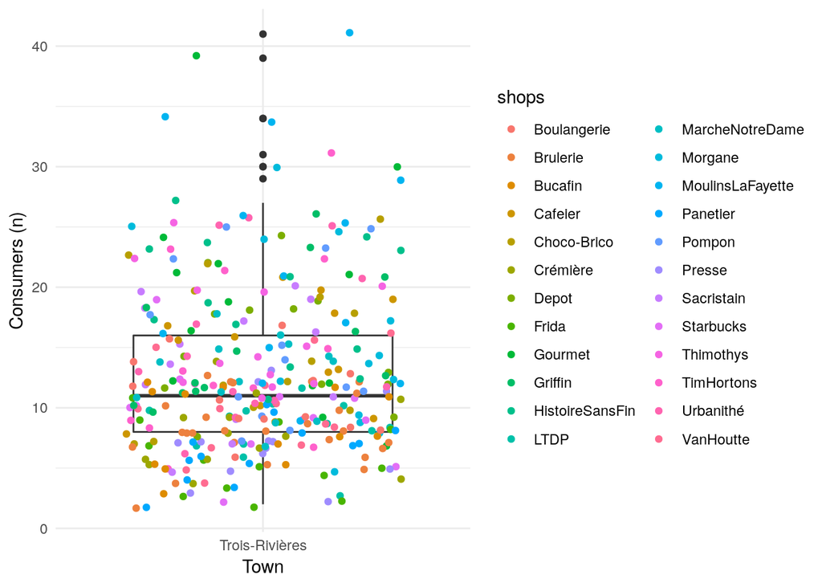

## Results

[figure not shown]

## Results

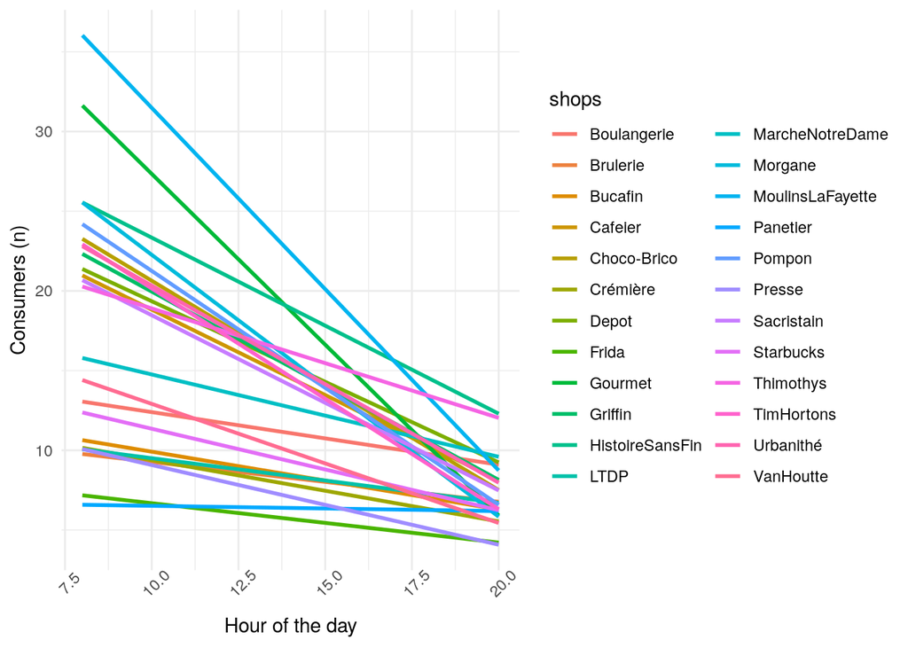

## Varying slope model

$$y_i \sim Poisson(\lambda_i)\\
\lambda_i = e^{\beta_0 + \beta_1hour + \beta_{s} + \beta_{1s}hour}\\$$

## Varying slope model: Hierarchical priors

In a varying slope model, we assume that the slope is potentially correlated with the intercepts. That make sens : a *cafe* almost empty in average might not lower variation during the day than a more popular *cafe*.

However, it might not be the case : a shop might be completely full at some time and completely empty at some other time, leading to a mean equal to the one of the population.

We will let the model determine the correlation between intercepts and slopes by defining the hierarchical prior of these parameters as a multivariate normal with mean 0 and estimated covariance matrix.

THe covariance matrix can be decomposed on diagonal matrices containing the standard-deviations of each parameters and a correlation matrix.

$$y_i \sim Poisson(\lambda_i)\\
\lambda_i = e^{\beta_0 + \beta_1hour + \beta_{s} + \beta_{1s}hour}\\
\begin{bmatrix}
\beta_s\\
\beta_{1s}\\
\end{bmatrix} = MVNormal(\begin{bmatrix}0\\0\\\end{bmatrix}, S)\\
\begin{array}{c}
S = \begin{bmatrix}
\sigma_{\beta_s} & 0 \\
0 & \sigma_{\beta_{1s}}\\
\end{bmatrix}
\rho
\begin{bmatrix}
\sigma_{\beta_s} & 0\\
0 & \sigma_{\beta_{1s}}\\
\end{bmatrix}
\end{array}\\$$

## Varying slope model: Priors and hyperpriors

This decomposition of the covariance matrix allow to define different priors for the standard-deviation and for the correlation matrix.

I find that *hal-normal*, that is normal distribution [truncated at zero](https://en.wikipedia.org/wiki/Truncated_normal_distribution) are the best priors for standard-deviations.

The prior for correlation matrix is an [LKJ distribution](https://www.psychstatistics.com/2014/12/27/d-lkj-priors/), which is an extension of the beta distribution between -1 and 1.

$$y_i \sim Poisson(\lambda_i)\\
\lambda_i = e^{\beta_0 + \beta_1hour + \beta_{s} + \beta_{1s}hour}\\
\begin{bmatrix}
\beta_s\\
\beta_{1s}\\
\end{bmatrix} = MVNormal(\begin{bmatrix}0\\0\\\end{bmatrix}, S)\\
\begin{array}{c}
S = \begin{bmatrix}
\sigma_{\beta_s} & 0 \\
0 & \sigma_{\beta_{1s}}\\
\end{bmatrix}
\rho
\begin{bmatrix}
\sigma_{\beta_s} & 0\\
0 & \sigma_{\beta_{1s}}\\
\end{bmatrix}
\end{array}\\
\rho \sim LKJ(1)\\
\begin{aligned}
\sigma_s \sim N^+(0,1)\\
\sigma_{1s} \sim N^+(0,1)
\end{aligned}
\begin{aligned}
\beta_0 \sim N(0,5)\\
\beta_1 \sim N(0,5)
\end{aligned}$$

## Simulate from the data generating process

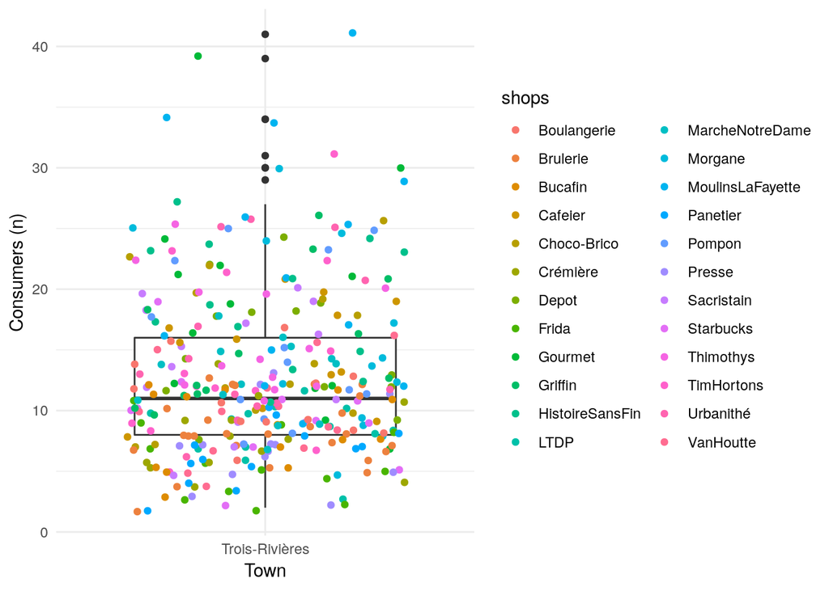

```r
## Create a data frame
X_long <- data.frame(shops = rep(shops, each = length(8:20)),
                     hour = scale(rep(8:20, length(shops))),
                     hour_unscale = rep(8:20, length(shops)))

## Create a design matrix for intercepts
X_int <- build.x(~ shops, X_long, contrasts = F)[,-1]
## Create a design matrix for slopes
X_slope <- build.x(~ shops:hour, X_long, contrasts = F)[,-1]

## Load libraries : truncated normal and multivariate normal distributions
library(rethinking)
library(truncnorm)

## Set the random seed
set.seed(999)

## Sample from the priors
hyper_sigma <- rtruncnorm(2, a = 0, 1, 1) # Hyperprior for hierarchical standard-deviations (intercepts and slopes)
hyper_rho <- rlkjcorr(n = 1, K = 2, eta = 0.1) # Hyperprior for the correlation matrix
b_0 <- rnorm(1, log(10), 1) # Prior for the global intercept
b_1 <- rnorm(1, 0, 1) # Prior for the global slope
## Hierarchical prior for the shops' intercept and slope
bs_shops <- rmvnorm2(n = ncol(X_int),Mu = c(0,0), Rho = hyper_rho, sigma = hyper_sigma)
b_shops <- bs_shops[,1]
b_1shops <- bs_shops[,2]
## Compute linear predictor
mu <- exp(b_0 + b_1 * X_long$hour + X_int %*% b_shops + X_slope %*% b_1shops)

## Sample observations
y <- rpois(nrow(X_int), mu)

D <- data.frame(shops = X_long$shops, hour = X_long$hour,
                hour_unscale = X_long$hour_unscale,
                consumers = y,
                town = "Trois-Rivières",
                type = "Observed")

D %>% ggplot(aes(x = town, y = consumers)) +
  geom_boxplot() +
  geom_point(aes(col = shops), position = "jitter") +
  xlab("Town") +
  ylab("Consumers (n)") +
  theme_minimal()
```

## Simulate from the data generating process

[figure not shown]

```r
D %>% mutate(shops = reorder(.$shops, .$consumers, median, na.rm = T)) %>%
  ggplot(aes(x = shops, y = consumers, col = shops)) +
  geom_boxplot() +
  guides(color = F) +
  theme_minimal() +
  xlab("Shops") +
  ylab("Consumers (n)") +
  theme(axis.text.x = element_text(angle=45))
```

## Simulate from the data generating process

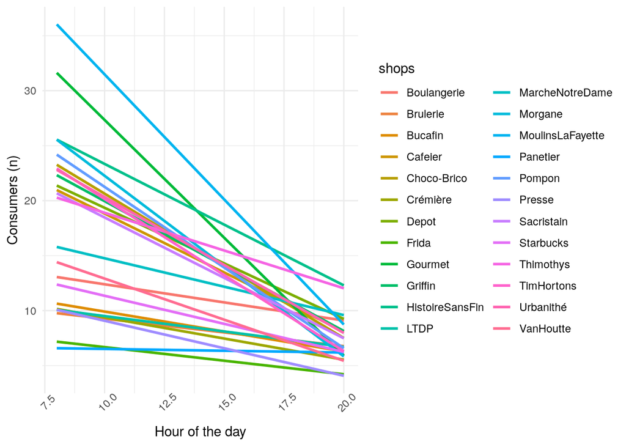

```r
D %>%
  ggplot(aes(x = hour_unscale, y = consumers, col = shops)) +
  geom_smooth(se = F, method = "gam") +
  xlab("Hour of the day") +
  ylab("Consumers (n)") +
  theme_minimal() +
  theme(axis.text.x = element_text(angle=45))
```

## Fit the varying slope model with `brms`

```r
## Formula
form_varslope <- bf(consumers ~ hour + (1+hour|shops), family = poisson)

## Get priors
get_prior(form_varslope, data = D)

## Define priors
priors_varslope <- c(prior(normal(0,5), class = Intercept),
                     prior(normal(0,2), class = sd),
                     prior(normal(0,5), class = b))

## Sample from the posterior
fit_varslope <- brm(formula = form_varslope, prior = priors_varslope,
                    data = D, iter = 2000,
                    chains = 4, cores = 4)
fit_varslope
```

## Check the sampling

```r
fit_varslope
```

```
 Family: poisson
  Links: mu = log
Formula: consumers ~ hour + (1 + hour | shops)
   Data: D (Number of observations: 325)
Samples: 4 chains, each with iter = 2000; warmup = 1000; thin = 1;
         total post-warmup samples = 4000

Group-Level Effects:
~shops (Number of levels: 24)
                    Estimate Est.Error l-95% CI u-95% CI Eff.Sample Rhat
sd(Intercept)           0.37      0.06     0.27     0.50        707 1.01
sd(hour)                0.09      0.02     0.05     0.14       1470 1.00
cor(Intercept,hour)    -0.81      0.16    -0.99    -0.41       1991 1.00

Population-Level Effects:
          Estimate Est.Error l-95% CI u-95% CI Eff.Sample Rhat
Intercept     2.45      0.08     2.30     2.60        503 1.01
hour         -0.25      0.02    -0.30    -0.20        971 1.01

Samples were drawn using sampling(NUTS). For each parameter, Eff.Sample
is a crude measure of effective sample size, and Rhat is the potential
scale reduction factor on split chains (at convergence, Rhat = 1).
```

```r
plot(fit_varslope)
```

## Posterior predictive checks

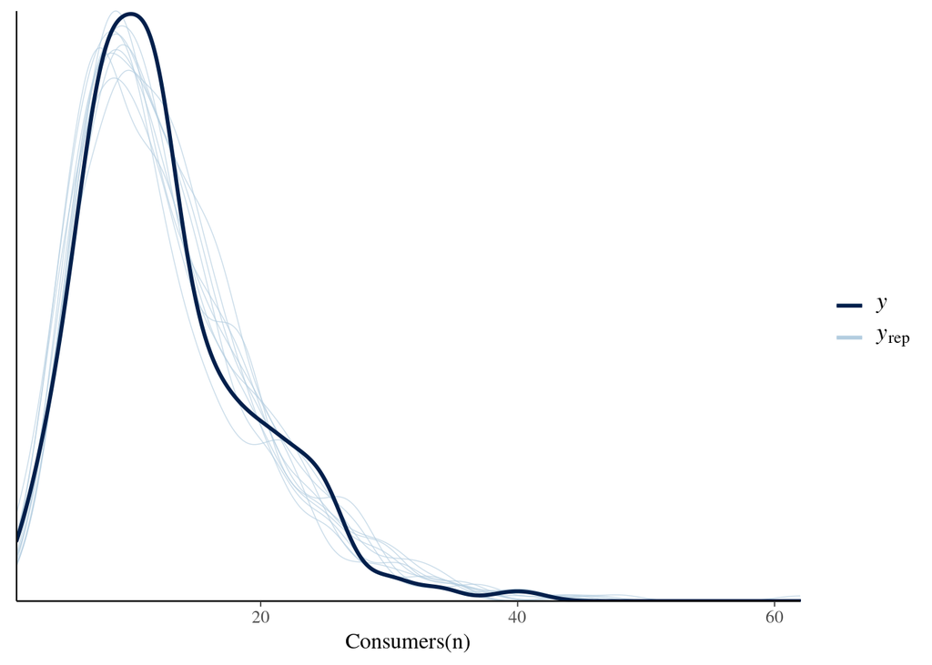

```r
pp_check(fit_varslope, type = "dens_overlay") +
  xlab("Consumers(n)")
```

## Posterior predictive checks

[figure not shown]

```r
pp_check(fit_varslope, type = "scatter_avg_grouped", group = "shops") +
  geom_abline(intercept = 0, slope = 1)
```

## Fit a non-hierarchical slope model with `brms`

```r
## Formula
form_slope <- bf(consumers ~ shops + hour + shops:hour, family = poisson)

## Get priors
get_prior(form_slope, data = D)

## Define priors
priors_slope <- c(prior(normal(0,5), class = Intercept),
                     prior(normal(0,5), class = b))

## Sample from the posterior
fit_slope <- brm(formula = form_slope, prior = priors_slope,
                    data = D, iter = 2000,
                    chains = 4, cores = 4)
fit_slope
```

## Check the sampling

```r
fit_slope
```

```
 Family: poisson
  Links: mu = log
Formula: consumers ~ shops + hour + shops:hour
   Data: D (Number of observations: 325)
Samples: 4 chains, each with iter = 2000; warmup = 1000; thin = 1;
         total post-warmup samples = 4000

Population-Level Effects:
                           Estimate Est.Error l-95% CI u-95% CI Eff.Sample
Intercept                      2.39      0.09     2.23     2.55        231
shopsBrulerie                 -0.29      0.11    -0.50    -0.08        348
shopsBucafin                  -0.28      0.13    -0.54    -0.03        603
shopsCafeier                   0.24      0.11     0.02     0.46        442
shopsChocoMBrico               0.28      0.11     0.06     0.51        386
shopsCrémière                 -0.36      0.13    -0.63    -0.10        545
shopsDepot                     0.30      0.11     0.08     0.52        403
shopsFrida                    -0.68      0.15    -0.97    -0.40        679
shopsGourmet                   0.44      0.11     0.22     0.66        375
shopsGriffin                   0.28      0.11     0.06     0.50        456
shopsHistoireSansFin           0.52      0.11     0.31     0.73        350
shopsLTDP                     -0.29      0.13    -0.56    -0.03        462
shopsMarcheNotreDame           0.13      0.11    -0.09     0.36        446
shopsMorgane                   0.27      0.11     0.05     0.50        506
shopsMoulinsLaFayette          0.64      0.11     0.43     0.84        397
shopsPanetier                 -0.55      0.14    -0.83    -0.28        677
shopsPompon                    0.27      0.11     0.04     0.48        406
shopsPresse                   -0.49      0.14    -0.76    -0.22        640
shopsSacristain                0.20      0.12    -0.02     0.44        437
shopsStarbucks                -0.19      0.13    -0.44     0.06        531
shopsThimothys                 0.37      0.11     0.15     0.58        373
shopsTimHortons                0.22      0.11    -0.01     0.44        432
shopsUrbanithé                 0.29      0.11     0.07     0.50        419
shopsVanHoutte                -0.15      0.12    -0.39     0.09        553
hour                          -0.12      0.08    -0.28     0.04        228
shopsBrulerie:hour             0.01      0.11    -0.20     0.21        370
shopsBucafin:hour             -0.04      0.13    -0.30     0.21        576
shopsCafeier:hour             -0.16      0.11    -0.38     0.06        427
shopsChocoMBrico:hour         -0.21      0.11    -0.43     0.00        349
shopsCrémière:hour            -0.06      0.13    -0.32     0.20        581
shopsDepot:hour               -0.13      0.11    -0.35     0.08        378
```

[output cut: 55 more lines]

```
shopsMorgane:hour          1.01
shopsMoulinsLaFayette:hour 1.01
shopsPanetier:hour         1.01
shopsPompon:hour           1.01
shopsPresse:hour           1.01
shopsSacristain:hour       1.01
shopsStarbucks:hour        1.01
shopsThimothys:hour        1.01
shopsTimHortons:hour       1.01
shopsUrbanithé:hour        1.01
shopsVanHoutte:hour        1.01

Samples were drawn using sampling(NUTS). For each parameter, Eff.Sample
is a crude measure of effective sample size, and Rhat is the potential
scale reduction factor on split chains (at convergence, Rhat = 1).
```

```r
plot(fit_slope)
```

## Parameter comparison

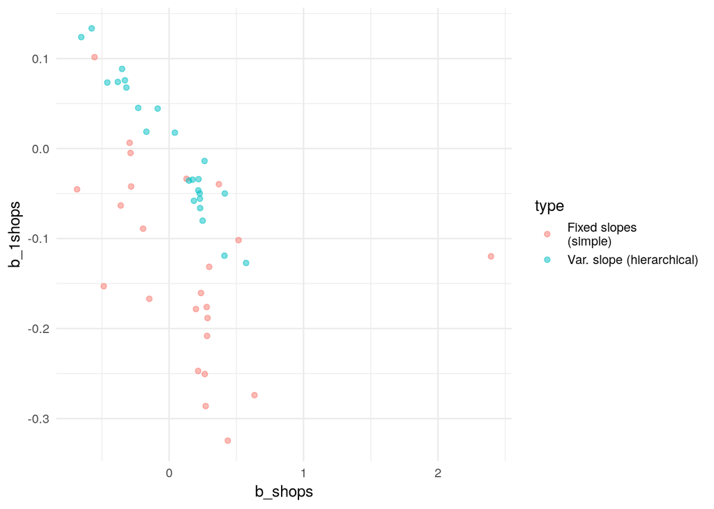

```r
# Extract classical model coefficients
## Extract mean intercepts
b_shops_fix <- fixef(fit_slope, probs = c(0.05, 0.95))[1:24,1]
## Extract mean slopes
b_1shops_fix <- fixef(fit_slope, probs = c(0.05, 0.95))[25:48,1]
## Assemble in a data frame
b_fix <- data.frame(type = "Fixed slopes\n(simple)", b_shops = b_shops_fix,
                    b_1shops = b_1shops_fix)

# Extract hierarchical model coefficient
## Extract mean intercepts
b_shops_var <- ranef(fit_varslope, probs = c(0.05, 0.95))$shops[,,1][,1]
## Extract mean slopes
b_1shops_var <- ranef(fit_varslope, probs = c(0.05, 0.95))$shops[,,2][,1]
## Assemble in a data frame
b_var <- data.frame(type = "Var. slope (hierarchical)", b_shops = b_shops_var,
                    b_1shops = b_1shops_var)

bind_rows(b_fix, b_var) %>%
  ggplot(aes(x = b_shops, y = b_1shops)) +
  geom_point(aes(col = type), alpha = 0.5) +
  theme_minimal()
```

## Model comparison : predictive density

```r
(loo_slope <- loo(fit_slope, cores = 2))
```

```
Computed from 4000 by 325 log-likelihood matrix

         Estimate   SE
elpd_loo   -864.1 11.2
p_loo        37.9  2.7
looic      1728.2 22.4
------
Monte Carlo SE of elpd_loo is 0.1.

Pareto k diagnostic values:
                         Count Pct.    Min. n_eff
(-Inf, 0.5]   (good)     319   98.2%   993
 (0.5, 0.7]   (ok)         6    1.8%   793
   (0.7, 1]   (bad)        0    0.0%   <NA>
   (1, Inf)   (very bad)   0    0.0%   <NA>

All Pareto k estimates are ok (k < 0.7).
See help('pareto-k-diagnostic') for details.
```

```r
(loo_varslope <- loo(fit_varslope, cores = 2))
```

```
Computed from 4000 by 325 log-likelihood matrix

         Estimate   SE
elpd_loo   -854.3 11.2
p_loo        25.2  2.0
looic      1708.6 22.5
------
Monte Carlo SE of elpd_loo is 0.1.

All Pareto k estimates are good (k < 0.5).
See help('pareto-k-diagnostic') for details.
```

```r
print(loo_compare(loo_slope, loo_varslope), simplify = F)
```

```
             elpd_diff se_diff elpd_loo se_elpd_loo p_loo  se_p_loo looic
fit_varslope    0.0       0.0  -854.3     11.2        25.2    2.0   1708.6
fit_slope      -9.8       3.4  -864.1     11.2        37.9    2.7   1728.2
             se_looic
fit_varslope   22.5
fit_slope      22.4
```

The varying slopes model have possibily better predictive ability, even if it is uncertain (`elpd_dif`), but also have far lower effective number of parameters (`p_loo`)!

## Hierarchical model comparison : **No AIC!**

$$AIC = 2k - 2ln(\hat L)$$

In the AIC formula, the k represent the number of parameters, and is fixed (unlike the effective number of parameters)! $\hat L$ is the likelihood of the model.

Let’s observe what happen if we compare a simple slopes model to a varying slopes model with AIC and maximum likelihood…

```r
## Measure of model fit
logLik(glm_slope)
```

```
'log Lik.' -818.1366 (df=48)
```

```r
logLik(glmer_varslope)
```

```
'log Lik.' -878.723 (df=5)
```

```r
## AIC
AIC(glm_slope, glmer_varslope)
```

```
               df      AIC
glm_slope      48 1732.273
glmer_varslope  5 1767.446
```

# Prior predictive checks

## Prior predictive checks

It is possible to verify that the priors are appropriates by computing predictions with parameters only sampled from the priors. We will see that our previous prior were terrible, producing absolutly ridiculous values. We should think more about them!

```r
## Sample from the priors
Prior_fit <- update(object = fit_varslope, recompile = F,
                     iter = 500, cores = 1, chains = 1,
                     sample_prior = "only")
```

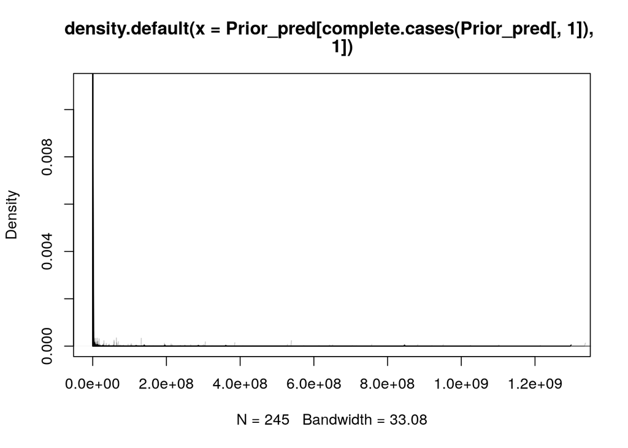

```r
## Compute predictions
Prior_pred <- predict(Prior_fit, summary = F)

## Plot the predictions
plot(density(Prior_pred[complete.cases(Prior_pred[,1]),1]))
for(j in 2:50) lines(density(Prior_pred[complete.cases(Prior_pred[,j]),j]),
                     col = scales::alpha(1,0.2))
```

# More and more…

## More and more…

We just entered the world of hierarchical models… But the concept of *adaptive prior* can be derived infinitly. Among some example:

- We can make the slope of a category dependant on other predictors
- “Continuous categories” and gaussian processes (phylogeny, space, time, smoothing)
- Shrinkage priors (horseshoe, finnish horseshoe…)

# Exercises

## Exercises

- Could you add a level in the varying intercept model decribing the sampling in different towns?
- Could you make the slopes between the hour of the day and the number of consumer depedant on the shop area?